# Taylor Series for approximating ODEs

In code;

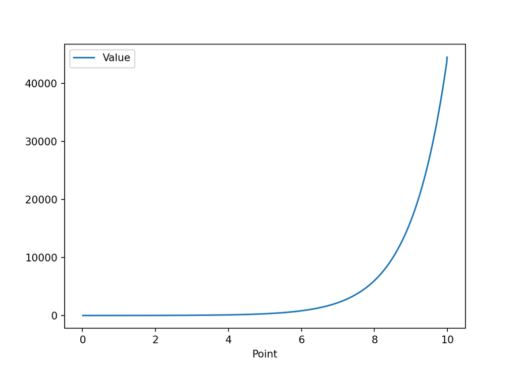

```python
#1
def c(vector, n ):

    return vector[1]
int_vector = [0,2]

#2
depth = 10
step = 0.01
d_min = 0.01
d_max = 10

#2.1 Set up output space
d_min_scale  = int(round(d_min / step))
d_max_scale = int(round(d_max / step))
ls_points = list(range(d_min_scale, d_max_scale))
ls_points = list(map(lambda x: x*step, ls_points))
df = pd.DataFrame(ls_points, columns=['Point'])
df['Value'] = 0
df.set_index('Point', inplace=True)


#2.2 Set up n list
ls_n = list(range(0,depth))

#3
def point(step, vector, ls_n, derivative):
    ls_point_term = []
    for n in ls_n:
        coefficient =  c(vector, n + derivative)
        point = coefficient / math.factorial(n) * step ** n
        ls_point_term.append(point)
    point_value = sum(ls_point_term)
    return point_value



point_vector = int_vector.copy()

while point_vector[0] <= d_max :
        point_values = []
        for d in range(0 , len(point_vector)- 1 ):
            value = point(step, point_vector, ls_n, d)
            point_values.append(value)

        location = df.index.get_loc(point_vector[0], method= 'nearest')
        df.iloc[location,0] = point_values[0]
        point_vector[0] += step
        point_vector[1:len(point_vector)]  = point_values


point_vector = int_vector.copy()

while point_vector[0] > d_min - step :
        point_values = []
        for d in range(0 , len(point_vector) - 1):
            value = point(-step, point_vector, ls_n, d)
            point_values.append(value)

        location = df.index.get_loc(point_vector[0], method= 'nearest')
        df.iloc[location,0] = point_values[0]
        point_vector[0] -= step
        point_vector[1:len(point_vector)] = point_values
df.plot()
```

So yay, we now have a method to model first order ODEs, but how will this work for higher order ODES?

The difference here is that for unique nth order ODES, a vector of n+1 values such that;

$$v = \langle x , f'(x) , ... , f^n(x) \rangle$$

Therefore, when creating a taylor series approximation, one of these vectors must be part of the description of the series. That means that at each step, not only the point value must be found, but also multiple nth order derivatives at the point as well.

Luckily, the taylor series has a simple derivative formula;

$$\mathbb F(x) = \sum_{n = 0}^{\infty} = \frac{\mathbb F^{n}(a)}{n!}\cdot(x - a)^n$$
$$\mathbb F'(x)= \sum_{n = 0}^{\infty} = \frac{\mathbb F^{n+1}(a)}{n!}\cdot(x - a)^n$$
$$\mathbb F^{m}(x)= \sum_{n = 0}^{\infty} = \frac{\mathbb F^{n+m}(a)}{n!}\cdot(x - a)^n$$

This means we can just expand the point function to return derivatives at points by offsetting n;

```python
def point(step, vector, ls_n, derivative):
    ls_point_term = []
    for n in ls_n:
        coefficient =  c(vector, n + derivative)
        point = coefficient / math.factorial(n) * step ** n
        ls_point_term.append(point)
    point_value = sum(ls_point_term)
    return point_value
```

We also need to alter the calculation loop to calculate multiple values per point.

[figure not shown]

```python
while point_vector[0] <= d_max :
        point_values = []
        for d in range(0 , len(point_vector)- 1 ):
            value = point(step, point_vector, ls_n, d)
            point_values.append(value)

        location = df.index.get_loc(point_vector[0], method= 'nearest')
        df.iloc[location,0] = point_values[0]
        point_vector[0] += step
        point_vector[1:len(point_vector)]  = point_values
```